# Relative and Absolute Age Dating

Dr. Ahmad Redaa

2024-09-18

# Introduction to Age Dating

- **Age dating** helps geologists determine the history of rock formations.
- **Relative age dating**: Determines the sequence of events.
- **Absolute age dating**: Assigns specific numerical ages.
- Importance: Understanding Earth’s geological timeline.

# Relative Age Dating

- The relative age dating is used to determine the chronological order of geological events without assigning a numerical age.
- Comparison of rock layers/unites to establish sequence.

# Principles of relative age dating

1. The Principle of Uniformitarianism
2. Principle of Original Horizontality
3. Principle of Superposition
4. Principle of Lateral Continuity
5. Law of Cross-Cutting Relationships
6. Principle of Inclusions
7. Principle of Faunal Succession

# The Principle of Uniformitarianism

- In 1785, James Hutton recognized that the present-day processes have operated throughout the geologic past.
- ‘‘The present is the key to the past’’ _ For Example: the phenomena of gravity and magnetism operated in the past pretty much as they do so today

# Principle of Original Horizontality

- Sediments are deposited in horizontal layers.
- Tilted layers indicate tectonic activity after deposition.

# Principle (Law) of Superposition

- In undisturbed sequences, the oldest layers are at the bottom, and the youngest at the top.

# Principle of Lateral Continuity

- The sediment extends laterally in all directions until it thins, pinches out, or terminates against the edge of the depositional basin
- Under normal conditions, deposits originally extended in all directions

# Law of Cross-Cutting Relationships

- An intrusion (e.g., igneous) or fault that cuts through another rock is younger than the rock it cuts
- Example: The intruding rock is always younger than the one it invades.

# Principle of Inclusions

- Rock fragments (inclusions) in a sedimentary layer must be older than the layer.
- Example: Pebbles in a conglomerate must have existed before the conglomerate formed.

# Principle of Faunal Succession

- Fossils appear in a well-defined order through geological time.
- Fossils can be used to establish relative age.

# Relative age dating - Summary

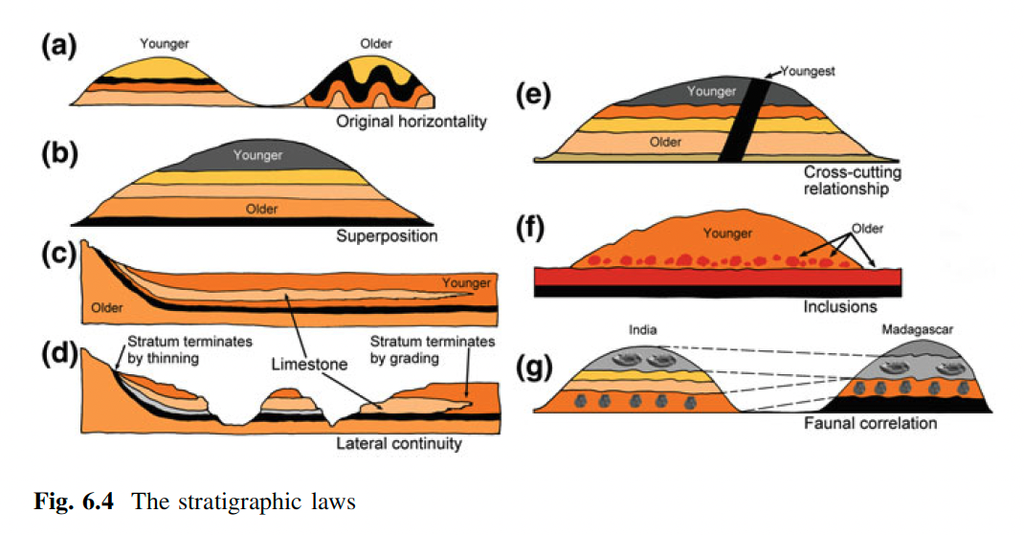

Source: [Jain, S. (2014)](https://doi.org/10.1007/978-81-322-1539-4)

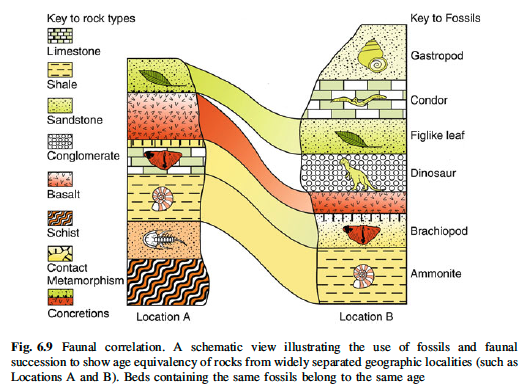

Source: [Jain, S. (2014)](https://doi.org/10.1007/978-81-322-1539-4)

# Absolute Age Dating

- **Absolute dating** assigns numerical ages to rocks.
- Based on isotopic dating methods.

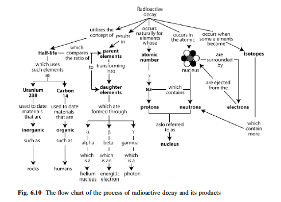

Source: [Jain, S. (2014)](https://doi.org/10.1007/978-81-322-1539-4)

# Isotopic Dating Methods

- **Radioactive Decay**: Radioactive elements break down over time, providing a clock for dating rocks.
  - **Carbon-14 Dating**: For recent fossils (up to ~50,000 years).
  - **Uranium-Lead Dating**: For older rocks (millions to billions of years).
  - **Potassium-Argon Dating**: Used for volcanic rocks.

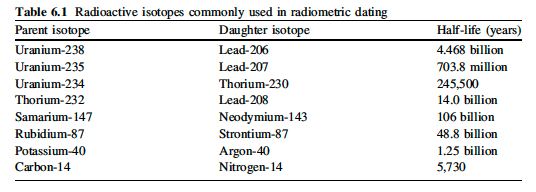

Source: [Jain, S. (2014)](https://doi.org/10.1007/978-81-322-1539-4)

# Further reading

- Earle, S., 2019. Chapter 8 Measuring Geological Time. Physical Geology-2nd Edition.
- Jain, S., 2014. Chapter 6 The Geological Timescale. Fundamentals of physical geology. New Delhi, Springer India.